# Linear Regression Part I - Session 7

# What you will learn today

- how to familiarise with a new data set (airbnb data set)
- how to derive regression coefficient estimates by hand
- how to run a linear regression model
- how to interpret it

# Recap

## in simple terms:

Linear regression answers the question: “If I know one thing (like years worked in company), what can I predict about another thing (like income)?” The line we draw helps us make these predictions. The goal is to make the best guess possible about how the two things are related.

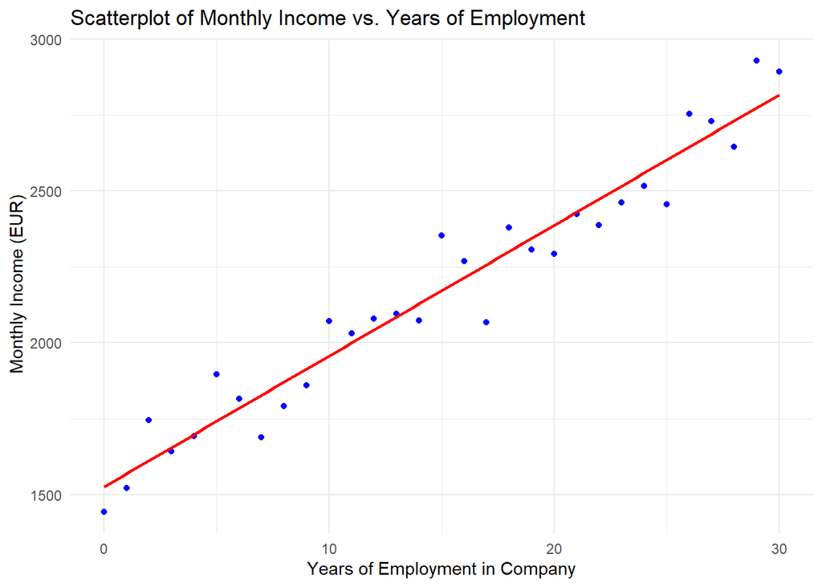

```r
# Load the necessary ggplot2 library
library(ggplot2)

# Set a seed for reproducibility
set.seed(123)

# Generate random data for years of employment
years_of_employment <- seq(0, 30, by = 1)  # 0 to 30 years

# Create income based on years of employment with a reasonable starting value
income <- 1500 + 45 * years_of_employment + rnorm(length(years_of_employment), mean = 0, sd = 100)  # Adding random noise

# Create a data frame
data <- data.frame(years_of_employment, income)

# Create the scatterplot with the linear regression line
ggplot(data, aes(x = years_of_employment, y = income)) +
  geom_point(color = "blue") +  # Add points
  geom_smooth(method = "lm", color = "red", se = FALSE) +  # Add linear regression line
  labs(title = "Scatterplot of Monthly Income vs. Years of Employment",
       x = "Years of Employment in Company",
       y = " Monthly Income (EUR)") +
  theme_minimal()
```

The equation of a simple linear regression can be expressed as: $y=β0+β1x$

```r
# Create a data frame
data <- data.frame(years_of_employment, income)

# Fit the linear model for income vs. years of employment
model <- lm(income ~ years_of_employment, data = data)

# Get the coefficients
coefficients <- summary(model)$coefficients

# Extracting beta0 and beta1
beta0hat <- coefficients[1, 1]  # Intercept (b0 hat)
beta1hat <- coefficients[2, 1]  # Slope (b1 hat)

# Print the coefficients
cat("Intercept (β0 hat):", beta0hat, "\n")
```

```
Intercept (β0 hat): 1525.964
```

```r
cat("Slope (β1 hat):", beta1hat, "\n")
```

```
Slope (β1 hat): 43.05686
```

What do the coefficients tell us?

# Digging deeper into the formulas:

real world: $y_i = \beta_0 + \beta_1 x_i + u_i$

our model: $\hat{y_i} = \hat{\beta_0} + \hat{\beta_1} x_i$

**important formulas:**

*RSS*
$$RSS = \sum_{i=1}^{n} \left(y_i - \hat{y_i} \right)^2 = \sum_{i=1}^{n} \left(y_i - \hat{\beta_0} - \hat{\beta_1} x_i \right)^2$$

RSS (residual sum of squares) should be minimized

*Covariance*

$Cov(x, y) = \frac{1}{n} \sum_{i=1}^n (x_i - E(x)) (y_i - E(y)) \\= \frac{1}{n} \sum_{i=1}^n (x_i - \bar{x}) (y_i - \bar{y})$

*Calculating the coefficients*

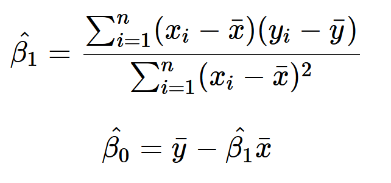

## commands to run a linear regression:

```r
library(sozoekds)
airbnbsmall<- airbnbsmall
```

We want to know how the cleaning fee can be explained by the number of beds (x ~ y)

```r
usd_cleaning_fee <- airbnbsmall$usd_cleaning_fee
n_beds <- airbnbsmall$n_beds
lm(usd_cleaning_fee ~ n_beds)
```

```
Call:
lm(formula = usd_cleaning_fee ~ n_beds)

Coefficients:
(Intercept)       n_beds
      14.43        11.64
```

Interpretation: For a flat with zero beds the cleaning fee would be on average 14.43$. By each additional bed the cleaning fee would rise up by 11.64$

Does this sound reasonable to us? Paying more for the cleaning of the flat if it allows for more people to sleep there sounds legit.

# Exercises

Create a .qmd-file and solve the tasks there. Store it in the JupyterHub folder “Session 7”.

Please use the airbnbsmall data set. Use our package “sozoekds” to load the data set. Make sure to have installed the package first.

Some of you had difficulties using this package.

This is why we have created a workaround:

Make sure, that the file called *data_sozoekds_package.RData* is copied into your working folder (click on it, then on more, then use copy-to and select your working folder)

```r
load("data_sozoekds_package.RData")
```

## 1) Make yourself familiar with the dataset:

1. How many observations does it comprise?
2. How many variables?

## 2) Linear Regression:

1. Think about a simple linear regression model with one exogenous variable explaining “price” (= endogenous variable). Write down the equation of your model.  
   Note: Do NOT use a variable that starts with d_ , those are dummy variables and will be handled later on
2. Calculate the intercept and regression coefficient estimate by hand. Remember the formula from the lecture (p.11).
3. Then, run the regression using a suitable R command. Compare your results to the ones you calculated by hand and interpret the coefficient and intercept.

## 3) Plotting

Plot the relationship of price and number of accommodates, include a trend-line. Take a closer look at the plot and draw conclusions in terms of the explanatory power of the model.